# Week 3 - Kaggle Mini Project: Histopathologic Cancer Detection

**Note:** This project is part of a peer-reviewed assignment in week 3 of the course "Introduction to Deep Learning" from the CU Boulder, which counts towards the Master of Science in Data Science (MSDS) degree.

In this work, the *Histopathologic Cancer Detection* [kaggle challenge](https://www.kaggle.com/competitions/histopathologic-cancer-detection) is used, with the goal being able to "*identify metastatic tissue in histopathologic scans of lymph node sections*". The challenge is described as follows:

> In this competition, you must create an algorithm to identify metastatic cancer in small image patches taken from larger digital pathology scans. The data for this competition is a slightly modified version of the PatchCamelyon (PCam) benchmark dataset (the original PCam dataset contains duplicate images due to its probabilistic sampling, however, the version presented on Kaggle does not contain duplicates).

> PCam is highly interesting for both its size, simplicity to get started on, and approachability. [...]

```python
# Setup
import os
import numpy as np
import pandas as pd
import matplotlib.pyplot as plt
import seaborn as sns
import plotly.express as px
from skimage import io
import tensorflow as tf
```

## 1) Brief Description of the Problem and Data

AI has been widely used for medical image processing in recent years. This is due to the fact that AI models are able to match, or even surpass, expert-like accuracies in that field of application. This mini project is used as an introduction to medical image processing, using images from pathologic scans of lymph node sections. The goal is to classify the images with corresponding labels 0 (no cancer) and 1 (cancerous) using convolutional neural networks (CNN).

The training dataset consists of roughly 220.000 RGB images with dimension (96, 96, 3) and binary labels. "*A positive label indicates that the center 32x32px region of a patch contains at least one pixel of tumor tissue.*"

The test dataset of size ~57.000 is unlabeled and used to determine the score of the challenge. The scoring metric is the area under ROC.

A more detailed analysis - including example images - of the dataset can be found in the next section.

## 2) Exploratory Data Anaylsis (EDA), Visualizations, Cleaning and Preprocessing.

Further obvious cleaning steps are not necessary, besides dropping erroneous images that came up during training.

However, the description states that the cancerous cell is located in a 32x32 box in the center of the image, so cropping the original images to the section of interest reduces the computation effort for training and tuning. Further preprocessing steps include splitting the training set into a train and validation set for hyperparameter tuning.

```python
# Read df and file paths
path_train = 'W3_data/train/'
df_train = pd.read_csv('W3_data/train_labels.csv')
df_train.head(5)
```

|  | id | label |
| --- | --- | --- |
| 0 | f38a6374c348f90b587e046aac6079959adf3835 | 0 |
| 1 | c18f2d887b7ae4f6742ee445113fa1aef383ed77 | 1 |
| 2 | 755db6279dae599ebb4d39a9123cce439965282d | 0 |
| 3 | bc3f0c64fb968ff4a8bd33af6971ecae77c75e08 | 0 |
| 4 | 068aba587a4950175d04c680d38943fd488d6a9d | 0 |

```python
# Required reprocessing for training
df_train['id'] = df_train['id'].apply(lambda x: x + '.tif')
df_train['label'] = df_train['label'].astype(str)
```

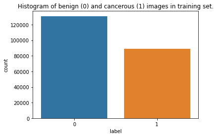

```python
# Count Histogram
sns.countplot(x=df_train['label']).set(title='Histogram of benign (0) and cancerous (1) images in training set.');
```

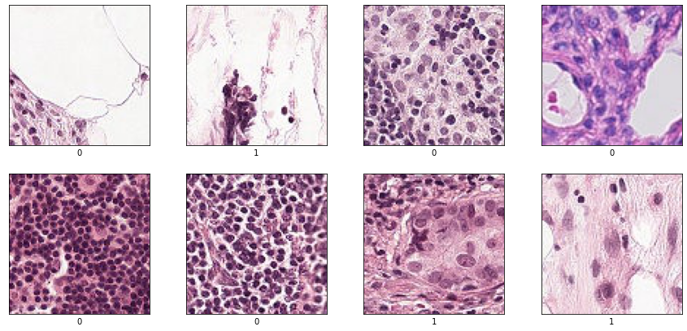

```python
# Sample images
fig, ax = plt.subplots(2, 4, figsize=(15, 7))
for i, axis in enumerate(ax.flat):
    file = path_train + df_train['id'][i]
    label = df_train['label'][i]
    image = io.imread(file)
    axis.imshow(image)
    axis.set(xticks=[], yticks=[], xlabel = label);
```

```python
# Preprocessing: Create image generator, and make train-valid-split (cropping is applied within the model)

BATCH_SIZE = 128

def crop_fn(img):
    return tf.image.central_crop(img, CROP_RATE)

gen = tf.keras.preprocessing.image.ImageDataGenerator(
    rescale=1./255.,
    validation_split=0.2,
    #preprocessing_function=crop_fn # crop images from center
)

gen_train = gen.flow_from_dataframe(
    dataframe=df_train,
    directory=path_train,
    x_col="id",
    y_col="label",
    subset="training",
    target_size=(96,96),
    batch_size=BATCH_SIZE,
    seed=42,
    class_mode="binary")

gen_valid = gen.flow_from_dataframe(
    dataframe=df_train,
    directory=path_train,
    x_col="id",
    y_col="label",
    subset="validation",
    target_size=(96,96),
    batch_size=BATCH_SIZE,
    seed=42,
    class_mode="binary")
```

```
Found 176020 validated image filenames belonging to 2 classes.
Found 44005 validated image filenames belonging to 2 classes.
```

## 3) Model Architecture

For this demo project, I am using a straight-forward CNN approach with similar state-of-the-art techniques to established CNN models such as AlexNet, i.e. increasing the number of kernels in each layer and adding dropout and pooling layers for regularization. The most important hyperparameters can be modified in order to make tuning them more efficient. To simplify things, I am fixing the number of convolutional layers to three, and the number of dense layers to two as well as the kernel size to (3,3), pooling size to (2,2) activation function to ReLU and Adam as optimizer.

A pretty shallow model with only about 10.300 parameters gets an already quite decent validation AUC of 0.8872.

```python
N_EPOCHS = 10
CROP_RATE = 0.5
```

```python
# Define model

def get_model(n_filt_1=8, n_filt_2=8, n_filt_3=16, n_dense=32, dropout_rate=0.2, lr_adam=0.0001):
    # returns compiled model with hyperparameters according to inputs

    mod = tf.keras.Sequential()

    # Cropping
    mod.add(tf.keras.layers.Lambda(lambda img: tf.image.central_crop(img, CROP_RATE)))

    # Convolutional Layer 1
    mod.add(tf.keras.layers.Conv2D(filters=n_filt_1, kernel_size=(3,3), activation='relu'))
    mod.add(tf.keras.layers.MaxPooling2D(pool_size=(2,2)))
    mod.add(tf.keras.layers.Dropout(dropout_rate))
    mod.add(tf.keras.layers.BatchNormalization())

    # Convolutional Layer 2
    mod.add(tf.keras.layers.Conv2D(filters=n_filt_2, kernel_size=(3,3), activation='relu'))
    mod.add(tf.keras.layers.AveragePooling2D(pool_size=(2,2)))
    mod.add(tf.keras.layers.Dropout(dropout_rate))
    mod.add(tf.keras.layers.BatchNormalization())

    # Convolutional Layer 3
    mod.add(tf.keras.layers.Conv2D(filters=n_filt_3, kernel_size=(3,3), activation='relu'))
    mod.add(tf.keras.layers.AveragePooling2D(pool_size=(2,2)))
    mod.add(tf.keras.layers.Dropout(dropout_rate))
    mod.add(tf.keras.layers.BatchNormalization())

    # Dense Layer
    mod.add(tf.keras.layers.Flatten())
    mod.add(tf.keras.layers.Dense(n_dense, activation='relu'))

    # Output Layer
    mod.add(tf.keras.layers.Dense(1, activation='sigmoid'))

    mod.build(input_shape=(BATCH_SIZE, 96, 96, 3))

    opt = tf.keras.optimizers.Adam(learning_rate=lr_adam)
    mod.compile(loss='binary_crossentropy', metrics=['accuracy', tf.keras.metrics.AUC()], optimizer=opt)

    print(mod.summary())

    return mod

baseline_model = get_model()
```

```
Model: "sequential_21"
_________________________________________________________________
Layer (type)                 Output Shape              Param #
=================================================================
lambda_4 (Lambda)            (128, 48, 48, 3)          0
_________________________________________________________________
conv2d_57 (Conv2D)           (128, 46, 46, 8)          224
_________________________________________________________________
max_pooling2d_19 (MaxPooling (128, 23, 23, 8)          0
_________________________________________________________________
dropout_57 (Dropout)         (128, 23, 23, 8)          0
_________________________________________________________________
batch_normalization_57 (Batc (128, 23, 23, 8)          32
_________________________________________________________________
conv2d_58 (Conv2D)           (128, 21, 21, 8)          584
_________________________________________________________________
average_pooling2d_38 (Averag (128, 10, 10, 8)          0
_________________________________________________________________
dropout_58 (Dropout)         (128, 10, 10, 8)          0
_________________________________________________________________
batch_normalization_58 (Batc (128, 10, 10, 8)          32
_________________________________________________________________
conv2d_59 (Conv2D)           (128, 8, 8, 16)           1168
_________________________________________________________________
average_pooling2d_39 (Averag (128, 4, 4, 16)           0
_________________________________________________________________
dropout_59 (Dropout)         (128, 4, 4, 16)           0
_________________________________________________________________
batch_normalization_59 (Batc (128, 4, 4, 16)           64
_________________________________________________________________
flatten_19 (Flatten)         (128, 256)                0
_________________________________________________________________
dense_38 (Dense)             (128, 32)                 8224
_________________________________________________________________
dense_39 (Dense)             (128, 1)                  33
=================================================================
Total params: 10,361
Trainable params: 10,297
Non-trainable params: 64
_________________________________________________________________
None
```

```python
# Train baseline model
baseline_hist = baseline_model.fit_generator(
                        gen_train,
                        epochs = N_EPOCHS,
                        validation_data = gen_valid)
```

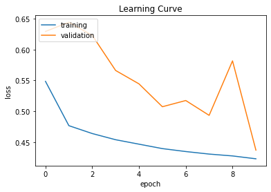

```python
def plot_learning_curve(hist):
    history = hist.history
    plt.plot(history['loss'])
    plt.plot(history['val_loss'])
    plt.title('Learning Curve')
    plt.ylabel('loss')
    plt.xlabel('epoch')
    plt.legend(['training', 'validation'], loc='upper left')
    plt.show();

plot_learning_curve(baseline_hist)
```

## 4) Tuning, Results and Analysis

Even with center-cropping and a small model, training a single epoch on my device took quite a long time. For this reason, I decided to train only one additional model with a larger number of parameters to see how much more performance can be gained by increasing the total number of trainable parameters.

The deeper model gets AUC scores of around 0.90, which suggests that even deeper models (and more epochs) would increase the accuracy further.

```python
deeper_model = get_model(n_filt_1=16, n_filt_2=16, n_filt_3=32, n_dense=32)
```

```
Model: "sequential_22"
_________________________________________________________________
Layer (type)                 Output Shape              Param #
=================================================================
lambda_5 (Lambda)            (128, 48, 48, 3)          0
_________________________________________________________________
conv2d_60 (Conv2D)           (128, 46, 46, 16)         448
_________________________________________________________________
max_pooling2d_20 (MaxPooling (128, 23, 23, 16)         0
_________________________________________________________________
dropout_60 (Dropout)         (128, 23, 23, 16)         0
_________________________________________________________________
batch_normalization_60 (Batc (128, 23, 23, 16)         64
_________________________________________________________________
conv2d_61 (Conv2D)           (128, 21, 21, 16)         2320
_________________________________________________________________
average_pooling2d_40 (Averag (128, 10, 10, 16)         0
_________________________________________________________________
dropout_61 (Dropout)         (128, 10, 10, 16)         0
_________________________________________________________________
batch_normalization_61 (Batc (128, 10, 10, 16)         64
_________________________________________________________________
conv2d_62 (Conv2D)           (128, 8, 8, 32)           4640
_________________________________________________________________
average_pooling2d_41 (Averag (128, 4, 4, 32)           0
_________________________________________________________________
dropout_62 (Dropout)         (128, 4, 4, 32)           0
_________________________________________________________________
batch_normalization_62 (Batc (128, 4, 4, 32)           128
_________________________________________________________________
flatten_20 (Flatten)         (128, 512)                0
_________________________________________________________________
dense_40 (Dense)             (128, 32)                 16416
_________________________________________________________________
dense_41 (Dense)             (128, 1)                  33
=================================================================
Total params: 24,113
Trainable params: 23,985
Non-trainable params: 128
_________________________________________________________________
None
```

```python
deeper_hist = deeper_model.fit_generator(
                        gen_train,
                        epochs = N_EPOCHS,
                        validation_data = gen_valid)
```

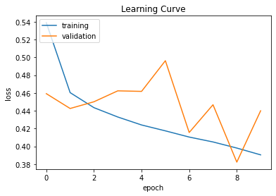

```python
plot_learning_curve(deeper_hist)
```

## 5) Prediction and Conclusion

This mini project was quite enjoyable, especially because it was fun to work with real-world medical images. It could be seen that decent scores can be achieved using CNNs. However, improving the model further is quite time consuming, because of the large training times. Apart from tuning the model architecture, several image preprocessing techniques could be applied to improve the dataset. This can be seen by looking at other solutions from this public playground competition. Without using leaked labels, accuracies >0.98 are achievable.

```python
path_test = 'W3_data/test/'
df_test = pd.DataFrame({'id':os.listdir(path_test)})

gen = tf.keras.preprocessing.image.ImageDataGenerator(rescale=1./255.)

gen_test = gen.flow_from_dataframe(
    dataframe=df_test,
    directory=path_test,
    x_col='id',
    y_col=None,
    target_size=(96,96),
    batch_size=1,
    shuffle=False,
    class_mode=None)
```

```
Found 57458 validated image filenames.
```

```python
preds = deeper_model.predict(gen_test, verbose=1)
```

```python
preds = np.transpose(preds)[0]
df_sub = pd.DataFrame()
df_sub['id'] = df_test['id'].apply(lambda x: x.split('.')[0])
df_sub['label'] = list(map(lambda x: 0 if x < 0.5 else 1, preds))
df_sub.head()
df_sub.to_csv('submission.csv', index=False)
```